# Zadání zápočtové úlohy

2024-05-30

## Instrukce

Zpracujte data o školách a školských zařízení v ČR. Zdroj dat [Adresář škol a školských zařízení MŠMT](http://stistko.uiv.cz/registr/vybskolrn.asp).

- Dle zadání zreprodukujte tabulky a grafy.
- Vypracujte Quarto report (nebo R Notebook) zobrazující nejen grafy a tabulky, ale také textový popis řešení.
- **Výsledný dokument ve formátu html nahrajte spolu se zdrojovými kódy (jednak R a jednak qmd včetně složek v případě Quarto reportu, nebo rmd v případě R Notebooku) na stránky předmětu v systému** [Moodle](https://moodle.prf.ujep.cz/course/view.php?id=753) **(neváhejte nahrát celou pracovní složku včetně zdrojových dat).**

K řešení se doporučuje využití těchto knihoven:

```r
library(dplyr)
library(ggplot2)
library(stringr)
library(lubridate)
library(tidyr)
```

## Úkol 1

Zjistěte počet škol a školských zařízení v jednotlivých okresech a zobrazte ho do mapy ČR. Pro instalaci a zobrazení mapy ČR využijte následující kód:

```r
install.packages("RCzechia")
```

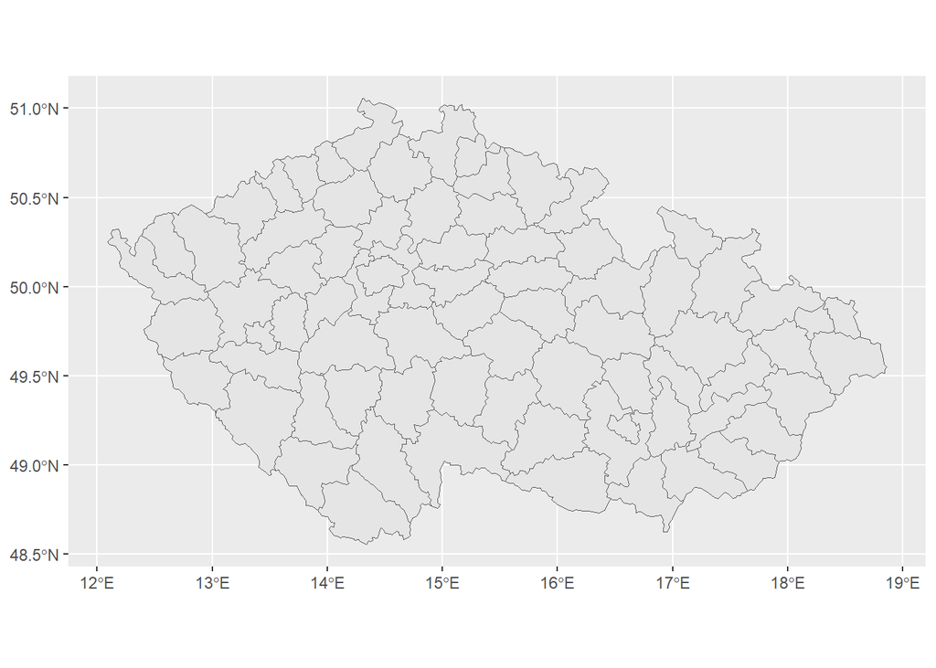

```r
library(RCzechia)
mapa <- okresy("low")

ggplot(data = mapa) + geom_sf()
```

Před zobrazením dat do mapy dbejte opatrnosti při práci s okresy. Kolik je okresů v tabulce `mapa` a kolik jich je v načteném souboru? Jaké názvy se liší? Rozdíly vyřešte za využití regulárních výrazů.

Nejprve uveďte tabulku 5 okresů s nejvyšším počtem škol a školských zařízení, potom zobrazte údaje za všechny okresy do mapy.

| Okres | n |
| --- | --- |
| Praha | 2367 |
| Brno-město | 834 |
| Brno-venkov | 642 |
| Olomouc | 642 |
| Ostrava-město | 584 |

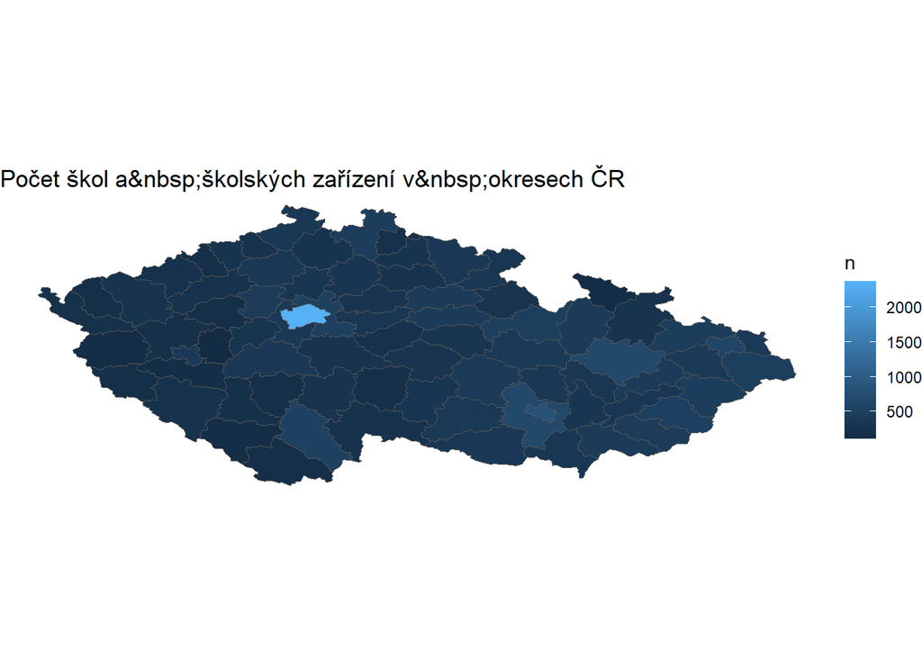

## Úkol 2

Jaký je časový vývoj počtu zakládaných škol v ČR? Zkontrolujte, zda jsou všechny časové záznamy ve správném formátu.

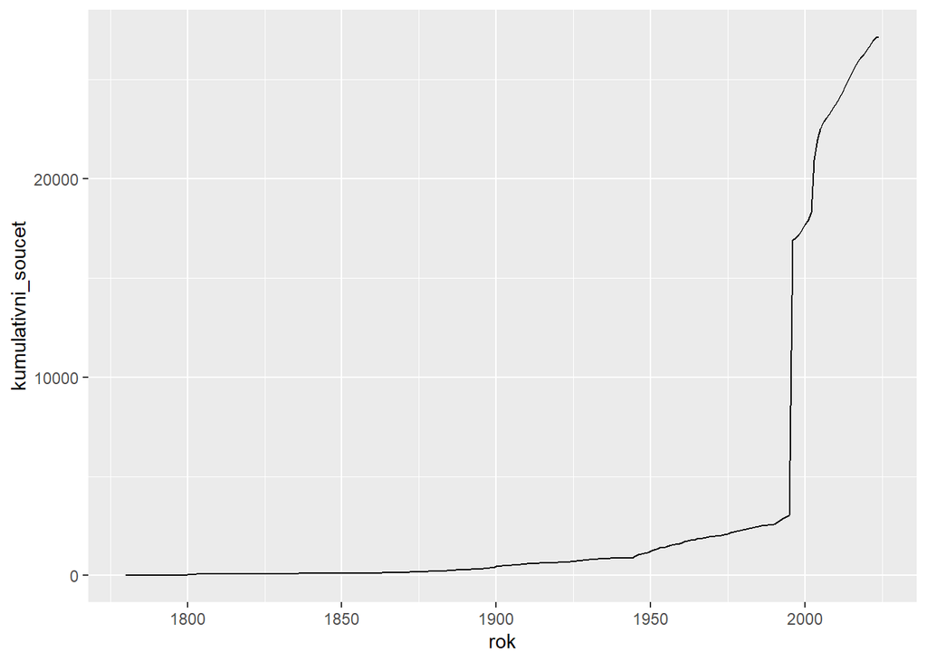

## Úkol 3

Jaké je zastoupení druhů škol bez školských institucí v jednotlivých okresech Ústeckého kraje? Ignorujte záznamy, které mají jen jeden výskyt. Tabulku seřaďte dle názvu okresu a chybějící záznamy nahraďte číslem 0.

| Okres | Mateřská škola | Základní škola | Střední škola | Základní umělecká škola | Vyšší odborná škola | Mateřská škola (lesní) |
| --- | --- | --- | --- | --- | --- | --- |
| Chomutov | 37 | 40 | 9 | 5 | 0 | 0 |
| Děčín | 64 | 54 | 20 | 4 | 2 | 2 |
| Litoměřice | 76 | 52 | 16 | 5 | 3 | 0 |
| Louny | 48 | 38 | 11 | 4 | 0 | 0 |
| Most | 22 | 30 | 17 | 3 | 0 | 0 |
| Teplice | 59 | 39 | 12 | 5 | 0 | 0 |
| Ústí nad Labem | 55 | 34 | 11 | 5 | 0 | 0 |

Vytvořte tabulku obsahující zkrácený název školy, jméno ředitele a e-mailovou adresu. V této tabulce budou použity pouze záznamy pro okres s největším celkovým počtem škol (založeno na tabulce výše). Uvádějte pouze unikátní záznamy.

|  | Zkrácený.název | Ředitel | Email.1 |
| --- | --- | --- | --- |
| 1 | LINGUA UNIVERSAL soukr. ZŠ a MŠ s.r.o. | Ing. Blanka Svobodová | info@zslingua.cz |
| 6 | SŠ pedagogická, hotelnictví a služeb | Pavla Matějková | skola@sslitomerice.cz |
| 9 | VOŠ,OA,SOŠ a JŠ s pr. SJZ EKONOM, o.p.s. | Ing. Jitka Nováková, DiS. | skolaekonom@skolaekonom.cz |
| 12 | Soukromá SOŠ (1. KŠPA), s.r.o. | Mgr. Ivana Jiřičová | litomerice@1kspa.cz |
| 13 | LITEGRA - SŠ a MŠ, o.p.s. | Mgr. Radek Šrejbr | info@litegra.cz |
| 17 | SOŠ technická a zahradnická | Mgr. Jiří Procházka | sekretariat@soslovo.cz |
| 21 | Gymnázium Josefa Jungmanna | RNDr. Bc. Radka Balounová, Ph.D. | gjj@gjj.cz |
| 22 | Gymnázium | Mgr. Petr Dobeš | gym-rce@seznam.cz |
| 24 | Soukromá podřipská SOŠ a SOU o.p.s. | Ing. Richard Červený | info@podripskaskola.cz |
| 25 | Soukromé SOU INDUSTRIA spol. s r.o. | Mgr. Lucie Vomáčková Kalkusová, Ph.D. | ssouindustria@seznam.cz |

[output cut: 121 more lines]